# airbnb

## Data Analysis of Listings at Airbnb

The dataset is scraped in 2019-04-17, which contains rich information about listings in Beijing.  
In this document:  
I'd like to visualize the following information:

1. geographical distribution of listings in Beijing
2. price distribution by listings charateristics

```python
%pylab inline
%matplotlib inline
import pandas as pd
pd.set_option('display.max_rows',None)
pd.set_option('display.max_columns',None)
import numpy as np
```

```python
path='D:/Data/airbnb/listings_detail.csv'
listings = pd.read_csv(path,parse_dates=['last_review'],low_memory=False,
                       dtype={'id':str,'host_id':str})
```

```python
listings.shape
```

```
(28452, 106)
```

## Data Cleaning

There are following issues:

1. drop variables with null value

```python
cols = ['listing_url','scrape_id','last_scraped','experiences_offered', 'thumbnail_url', 'medium_url',
       'picture_url', 'xl_picture_url', 'host_url','host_acceptance_rate', 'host_thumbnail_url',
        'host_picture_url','host_total_listings_count','neighbourhood_group_cleansed', 'country_code', 'country',
        'has_availability','calendar_last_scraped','requires_license','license','jurisdiction_names','is_business_travel_ready']
len(cols)
```

```
22
```

```python
listings = listings.drop(cols, axis=1)
listings.shape
```

```
(28452, 84)
```

```python
for col in listings.columns.values:
    print(col,listings[col].unique())
    print('\n')
```

[output not shown]

[output cut: 2200 more lines]

[output not shown]

```python
# count number of nan in each column
with_na = listings.isnull().sum()!=0
listings.isnull().sum()[with_na]
```

```
name                               1
summary                         3020
space                           9598
description                     2473
neighborhood_overview          10470
notes                          15274
transit                        10595
access                         13439
interaction                    12874
house_rules                    14622
host_location                    142
host_about                     10850
host_response_time              3438
host_response_rate              3438
host_neighbourhood             12669
neighbourhood                   7542
city                              75
state                             56
zipcode                         9599
market                             1
bathrooms                          6
bedrooms                          16
beds                              16
square_feet                    28434
weekly_price                   28063
monthly_price                  28056
security_deposit               17636
cleaning_fee                   16683
first_review                   11158
last_review                    11158
review_scores_rating           11555
review_scores_accuracy         11555
review_scores_cleanliness      11555
review_scores_checkin          11566
review_scores_communication    11556
review_scores_location         11578
review_scores_value            11578
reviews_per_month              11158
dtype: int64
```

```python
listings[listings.name.isnull()]
```

|  | id | name | summary | space | description | neighborhood_overview | notes | transit | access | interaction | house_rules | host_id | host_name | host_since | host_location | host_about | host_response_time | host_response_rate | host_is_superhost | host_neighbourhood | host_listings_count | host_verifications | host_has_profile_pic | host_identity_verified | street | neighbourhood | neighbourhood_cleansed | city | state | … |
| --- | --- | --- | --- | --- | --- | --- | --- | --- | --- | --- | --- | --- | --- | --- | --- | --- | --- | --- | --- | --- | --- | --- | --- | --- | --- | --- | --- | --- | --- | --- |
| 456 | 7775603 | NaN | ️ | ️ | ️ ️ ️ ️ ️ ️ | ️ | ️ | NaN | ️ | ️ | 不要大声喧哗,放大音响,不打扰邻居｡ | 14820763 | 张三 | 2014-04-28 | Beijing, Beijing, China | NaN | NaN | NaN | f | NaN | 1 | ['email', 'phone', 'reviews', 'weibo', 'sesame... | t | t | 北京市, 房山区, China | NaN | 房山区 | 北京市 | 房山区 | … |

```python
listings[listings.market.isnull()]
```

|  | id | name | summary | space | description | neighborhood_overview | notes | transit | access | interaction | house_rules | host_id | host_name | host_since | host_location | host_about | host_response_time | host_response_rate | host_is_superhost | host_neighbourhood | host_listings_count | host_verifications | host_has_profile_pic | host_identity_verified | street | neighbourhood | neighbourhood_cleansed | city | state | … |
| --- | --- | --- | --- | --- | --- | --- | --- | --- | --- | --- | --- | --- | --- | --- | --- | --- | --- | --- | --- | --- | --- | --- | --- | --- | --- | --- | --- | --- | --- | --- |
| 1193 | 13283298 | 国贸 附近 精装 公寓 | 我的房源靠近市中心､艺术和文化､优美的景色｡我的房源适合情侣和商务旅行者｡ | NaN | 我的房源靠近市中心､艺术和文化､优美的景色｡我的房源适合情侣和商务旅行者｡ | NaN | NaN | NaN | NaN | NaN | NaN | 19482030 | 爱民 | 2014-08-05 | Beijing, Beijing, China | NaN | within a day | 80% | f | Wai Avenue | 27 | ['email', 'phone', 'weibo', 'zhima_selfie'] | t | f | Beijing, Beijing Shi, China | Chaoyang | 朝阳区 / Chaoyang | Beijing | Beijing Shi | … |

```python
listings.shape
```

```
(28452, 84)
```

```python
listings = listings[-listings.name.isnull()]
listings = listings[-listings.market.isnull()]
listings = listings[-listings.beds.isna()]
listings = listings[-listings.bedrooms.isna()]
listings = listings[-listings.bathrooms.isna()]
listings.shape
```

```
(28421, 84)
```

```python
# any column with null value
listings.isnull().all().sum()
```

```
0
```

```python
# delete columns with all null values
listings = listings.dropna(axis=1, how='all')
listings.shape
```

```
(28421, 84)
```

```python
# any guest included equal to zero
f = lambda x:x==0
listings.guests_included.apply(f).sum()
```

```
0
```

```python
# any accommodates equal to zero
listings.accommodates.apply(f).sum()
```

```
0
```

```python
# any availability_365 equal to zero
listings.availability_365.apply(f).sum()
```

```
2621
```

```python
# delete unavailable listings in a year
listings = listings[listings.availability_365!=0]
listings.shape
```

```
(25800, 84)
```

```python
# any beds equal to zero
listings.beds.apply(f).sum()
```

```
388
```

## Data format

1. `price`: float
2. `price_0`: the ones digit of price
3. `price_00`: the tens digit of price
4. `weekly_price`: float
5. `monthly_price`: float
6. `host_response_rate`: int
7. `security_deposit`: float
8. `cleaning_fee`: float
9. `days_host`: days since host
10. `days_review`: days to first review
11. `host_is_superhost`: to dummy
12. `instant_bookable`: to dummy
13. `neibourhood_cleansed`:
14. `deposit`: 1/0

```python
# convert string price to numeric value
listings['price'] = listings.price.str.replace('$','').str.replace(',','').astype(float)
listings['weekly_price'] = listings.weekly_price.str.replace('$','').str.replace(',','').astype(float)
listings['monthly_price'] = listings.monthly_price.str.replace('$','').str.replace(',','').astype(float)
listings['security_deposit'] = listings.security_deposit.str.replace('$','').str.replace(',','').astype(float)
listings['cleaning_fee'] = listings.cleaning_fee.str.replace('$','').str.replace(',','').astype(float)
```

```python
# check whether all price is integer
listings['price_int'] = listings.price.astype(int)
listings['diff'] = listings['price'] - listings['price_int']
all(listings['diff']==0)
```

```
True
```

```python
listings.drop(['diff','price_int'], axis=1, inplace=True)
```

```python
# any price equal to zero
f = lambda x:x==0
listings.price.apply(f).sum()
```

```
3
```

```python
# delete zero price listings
zero_p = listings.price.apply(f)
listings = listings[-zero_p]
listings.shape
```

```
(25797, 84)
```

```python
# any price less than 10
f = lambda x:x<=10
listings.price.apply(f).sum()
```

```
0
```

```python
# ones and tens digit of price
listings['price_0'] = listings.price % 10
listings['price_00'] = listings.price // 10 % 10
```

```python
# convert string response to numeric value
listings['host_response_rate'] = listings.host_response_rate.str.replace('%','').astype(float)
listings.host_response_rate.unique()
```

```
array([100.,  71.,  nan,  50.,  92.,   0.,  86.,  33.,  97.,  83.,  80.,
        88.,  57.,  89.,  70.,  93.,  90.,  63.,  75.,  96.,  78.,  91.,
        60.,  99.,  25.,  44.,  29.,  69.,  67.,  55.,  79.,  95.,  40.,
        98.,  64.,  77.,  68.,  94.,  73.,  38.,  61.,  87.,  43.,  37.,
        56.,  48.,  17.,  85.,  82.,  76.,  62.,  20.,  47.,  81.,  58.,
        59.,  84.,  32.,  65.,  13.,  66.,  15.,  22.,  30.,  53.,  14.])
```

```python
from datetime import date
# specify as date
listings["host_since"] = pd.to_datetime(listings["host_since"]).dt.date
listings["first_review"] = pd.to_datetime(listings["first_review"]).dt.date
current = date(2019,4,17)
# convert timedelta to days
listings['days_host'] = (current - listings['host_since']).dt.days
listings['days_review'] = (current - listings['first_review']).dt.days
listings.days_review.isnull().sum()
```

```
10009
```

```python
#listings['instant_bookable'] = listings.instant_bookable.get_dummies()
d = {"t":1,"f":0}
f = lambda x: d[x]
listings['host_is_superhost'] = listings.host_is_superhost.apply(f)
listings['instant_bookable'] = listings.instant_bookable.apply(f)
listings['is_location_exact'] = listings.is_location_exact.apply(f)
listings['host_has_profile_pic'] = listings.host_has_profile_pic.apply(f)
listings['host_identity_verified'] = listings.host_identity_verified.apply(f)
listings['require_guest_profile_picture'] = listings.require_guest_profile_picture.apply(f)
listings['require_guest_phone_verification'] = listings.require_guest_phone_verification.apply(f)
```

```python
f = lambda x: x[:2]
listings['neighbourhood_cleansed'] = listings.neighbourhood_cleansed.apply(f)
listings['neighbourhood_cleansed'] = listings.neighbourhood_cleansed.str.replace('石景','石景山')
listings['neighbourhood_cleansed'] = listings.neighbourhood_cleansed.str.replace('门头','门头沟')
```

```python
# any cleaning_fee equal to zero
f = lambda x:x==0
listings.cleaning_fee.apply(f).sum()
```

```
3438
```

```python
# any security_deposit equal to zero
listings.security_deposit.apply(f).sum()
```

```
4388
```

```python
# any number of review equal to zero
# no null value
listings.number_of_reviews.apply(f).sum()
```

```
10009
```

```python
# convert nan to zero
listings.cleaning_fee.fillna(0,inplace=True)
listings.security_deposit.fillna(0,inplace=True)
```

```python
# specify deposit as an indicator of whether deposit is required
f = lambda x: 0 if x==0 else 1
listings['deposit'] = listings.security_deposit.apply(f)
listings.deposit.unique()
```

```
array([1, 0], dtype=int64)
```

```python
listings['cleanfee'] = listings.cleaning_fee.apply(f)
listings.cleanfee.unique()
```

```
array([1, 0], dtype=int64)
```

## Geographical distribution of listings

```python
import geopandas as gpd
# shapely, fiona都是geopandas内包含的
from shapely.geometry import Point # 经纬度转换为点
import mapclassify
import matplotlib.pyplot as plt
from matplotlib.collections import PatchCollection
import descartes
```

```python
# read spacial data as GeoDataFrame
bj_gdf = gpd.GeoDataFrame.from_file('D:/Data/airbnb/neighbourhoods.geojson')
bj_gdf.head()
```

|  | neighbourhood | neighbourhood_group | geometry |
| --- | --- | --- | --- |
| 0 | 东城区 | None | MULTIPOLYGON (((116.44231 39.90180, 116.44246 ... |
| 1 | 西城区 | None | MULTIPOLYGON (((116.39155 39.89710, 116.39157 ... |
| 2 | 昌平区 | None | MULTIPOLYGON (((116.04274 40.08406, 116.03750 ... |
| 3 | 大兴区 / Daxing | None | MULTIPOLYGON (((116.73473 39.62160, 116.69884 ... |
| 4 | 房山区 | None | MULTIPOLYGON (((116.24662 39.79181, 116.24320 ... |

```python
f = lambda x: x[:2]
bj_gdf['neighbourhood'] = bj_gdf.neighbourhood.apply(f)
bj_gdf['neighbourhood'] = bj_gdf.neighbourhood.str.replace('石景','石景山')
bj_gdf['neighbourhood'] = bj_gdf.neighbourhood.str.replace('门头','门头沟')
del bj_gdf['neighbourhood_group']
```

```python
# check values of neighborhood
bj_gdf.neighbourhood.unique()
```

```
array(['东城', '西城', '昌平', '大兴', '房山', '怀柔', '门头沟', '密云', '平谷', '延庆', '朝阳',
       '丰台', '海淀', '顺义', '通州', '石景山'], dtype=object)
```

```python
# zip the coordinates into a point object and convert to a GeoDataFrame
geometry = [Point(p) for p in zip(listings.longitude, listings.latitude)]
listings_gdf = gpd.GeoDataFrame(listings, geometry=geometry)
```

```python
# count number of listings per district
num_lst = listings_gdf.groupby("neighbourhood_cleansed").size()
# convert to dataframe
num_lst = num_lst.to_frame().reset_index()
# rename columns
num_lst.columns = ["neighbourhood", "lst"]
```

```python
# count number of beds per district
num_bed = listings_gdf.beds.groupby(listings.neighbourhood_cleansed).sum()
num_bed = num_bed.reset_index()
num_bed.columns = ["neighbourhood", "bed"]
```

```python
# count number of accommodates  per district
num_acmd = listings_gdf.accommodates.groupby(listings.neighbourhood_cleansed).sum()
num_acmd = num_acmd.reset_index()
num_acmd.columns = ["neighbourhood", "acmd"]
```

```python
# merge data
bj_gdf = pd.merge(bj_gdf, num_lst, on="neighbourhood", how="left")
bj_gdf = pd.merge(bj_gdf, num_bed, on="neighbourhood", how="left")
bj_gdf = pd.merge(bj_gdf, num_acmd, on="neighbourhood", how="left")
```

```python
# population by district
pop = [90.5,129.8,196.3,156.2,104.6,38.4,30.8,47.9,42.3,31.4,395.5,232.4,369.4,102,137.8,65.2]
bj_gdf['pop'] = pop
```

```python
bj_gdf['lst_pc'] = bj_gdf['lst']/bj_gdf['pop']
bj_gdf['bed_pc'] = bj_gdf['bed']/bj_gdf['pop']
bj_gdf['acmd_pc'] = bj_gdf['acmd']/bj_gdf['pop']
```

```python
bj_gdf
```

|  | neighbourhood | geometry | lst | bed | acmd | pop | lst_pc | bed_pc | acmd_pc |
| --- | --- | --- | --- | --- | --- | --- | --- | --- | --- |
| 0 | 东城 | MULTIPOLYGON (((116.44231 39.90180, 116.44246 ... | 3052 | 6274.0 | 11569 | 90.5 | 33.723757 | 69.325967 | 127.834254 |
| 1 | 西城 | MULTIPOLYGON (((116.39155 39.89710, 116.39157 ... | 1522 | 2865.0 | 5089 | 129.8 | 11.725732 | 22.072419 | 39.206471 |
| 2 | 昌平 | MULTIPOLYGON (((116.04274 40.08406, 116.03750 ... | 909 | 3476.0 | 4907 | 196.3 | 4.630667 | 17.707590 | 24.997453 |
| 3 | 大兴 | MULTIPOLYGON (((116.73473 39.62160, 116.69884 ... | 770 | 1488.0 | 2740 | 156.2 | 4.929577 | 9.526248 | 17.541613 |
| 4 | 房山 | MULTIPOLYGON (((116.24662 39.79181, 116.24320 ... | 552 | 1361.0 | 2182 | 104.6 | 5.277247 | 13.011472 | 20.860421 |
| 5 | 怀柔 | MULTIPOLYGON (((116.27899 40.37974, 116.27943 ... | 798 | 3534.0 | 5285 | 38.4 | 20.781250 | 92.031250 | 137.630208 |
| 6 | 门头沟 | MULTIPOLYGON (((115.56297 39.81206, 115.56156 ... | 134 | 319.0 | 537 | 30.8 | 4.350649 | 10.357143 | 17.435065 |
| 7 | 密云 | MULTIPOLYGON (((116.88258 40.79685, 116.89160 ... | 880 | 2833.0 | 4564 | 47.9 | 18.371608 | 59.144050 | 95.281837 |
| 8 | 平谷 | MULTIPOLYGON (((117.38129 40.22541, 117.38304 ... | 128 | 412.0 | 707 | 42.3 | 3.026005 | 9.739953 | 16.713948 |
| 9 | 延庆 | MULTIPOLYGON (((116.27899 40.37974, 116.27895 ... | 697 | 2399.0 | 3970 | 31.4 | 22.197452 | 76.401274 | 126.433121 |
| 10 | 朝阳 | MULTIPOLYGON (((116.56870 40.10941, 116.56956 ... | 9625 | 15996.0 | 28340 | 395.5 | 24.336283 | 40.445006 | 71.656131 |
| 11 | 丰台 | MULTIPOLYGON (((116.43726 39.87080, 116.43910 ... | 1625 | 2916.0 | 5542 | 232.4 | 6.992255 | 12.547332 | 23.846816 |
| 12 | 海淀 | MULTIPOLYGON (((116.32248 39.89564, 116.30838 ... | 2857 | 5033.0 | 8711 | 369.4 | 7.734164 | 13.624797 | 23.581483 |
| 13 | 顺义 | MULTIPOLYGON (((116.49032 40.25365, 116.49498 ... | 859 | 1767.0 | 3169 | 102.0 | 8.421569 | 17.323529 | 31.068627 |
| 14 | 通州 | MULTIPOLYGON (((116.58917 40.01649, 116.59197 ... | 1202 | 2019.0 | 3536 | 137.8 | 8.722787 | 14.651669 | 25.660377 |
| 15 | 石景山 | MULTIPOLYGON (((116.16118 39.88551, 116.16068 ... | 187 | 328.0 | 589 | 65.2 | 2.868098 | 5.030675 | 9.033742 |

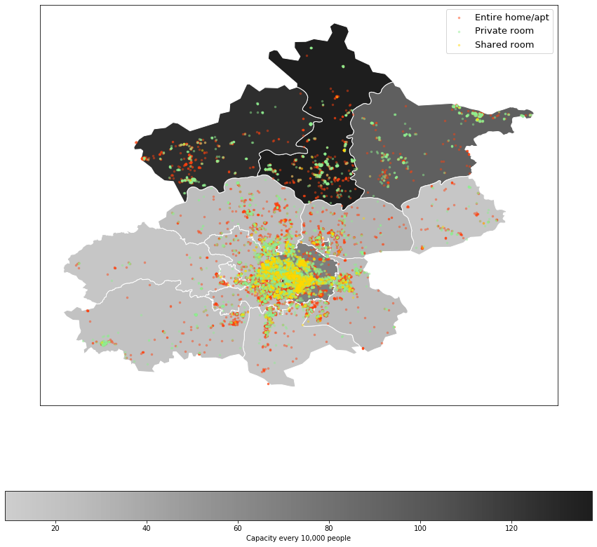

```python
from matplotlib import cm
from matplotlib.colors import ListedColormap, LinearSegmentedColormap
# create a new colormap from listed colormap, from lightness quantile 0.3-0.9
greys = cm.get_cmap('Greys', 512)
newcmp = ListedColormap(greys(np.linspace(0.30, 0.90, 256)))
# create map
base = bj_gdf.plot(column="acmd_pc", cmap=newcmp, edgecolor='white',legend=True,
                   legend_kwds={'label': "Capacity every 10,000 people", 'orientation': "horizontal"},
                   figsize=(15, 15))
# by room type condition
e = listings_gdf.room_type=='Entire home/apt'
p = listings_gdf.room_type=='Private room'
s = listings_gdf.room_type=='Shared room'
# plot listing point on map
listings_gdf[e].plot(ax=base, color='xkcd:orangered', marker="o", markersize=6, alpha=0.4, label='Entire home/apt')
listings_gdf[p].plot(ax=base, color='lightgreen', marker="o", markersize=6, alpha=0.4, label='Private room')
listings_gdf[s].plot(ax=base, color='gold', marker="o", markersize=6, alpha=0.4, label='Shared room')
#
plt.gca().xaxis.set_major_locator(plt.NullLocator())
plt.gca().yaxis.set_major_locator(plt.NullLocator())
plt.legend(loc="best",prop={'size': 13})
```

### Price distribution by characteristics

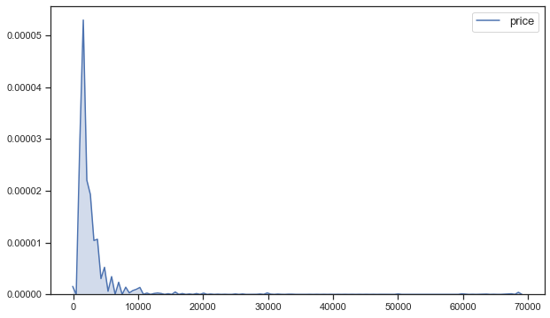

```python
import seaborn as sns
sns.set(style="ticks")
plt.figure(figsize=(10, 6))
sns.kdeplot(listings.price, shade=True)
plt.legend(prop={'size': 13})
```

```python
# adjust price range
sub_lst = listings[listings.price<2300]
sub_lst.shape
```

```
(24909, 91)
```

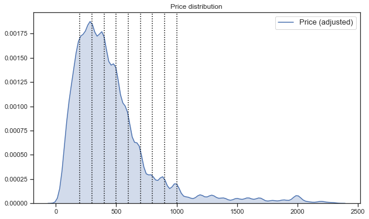

```python
plt.figure(figsize=(10, 6))
sns.kdeplot(sub_lst.price, shade=True, label='Price (adjusted)')
# vertical line indicating 200：1000
for i in range(200,1100,100):
    plt.axvline(i, c='black', ls=':')
plt.legend(prop={'size': 13})
plt.title('Price distribution')
```

```python
# adjust price range
pr_00 = (listings.price<1000) & (listings.price>=100)
sub_lst = listings[pr_00]
sub_lst.shape
```

```
(22601, 91)
```

```python
# alternative
sub_lst = listings.query('(price<1000) & (price>=100)')
sub_lst.shape
```

```
(22601, 91)
```

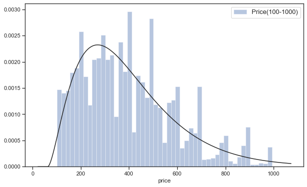

```python
from scipy import stats
plt.figure(figsize=(10, 6))
# to fit a parametric distribution to a dataset
sns.distplot(sub_lst.price, kde=False, fit=stats.gamma, label='Price(100-1000)')
plt.legend(prop={'size': 13})
```

```python
crosstab = pd.crosstab(sub_lst.price_0, sub_lst.price_00)
crosstab
```

| price_00 price_0 | 0.0 | 1.0 | 2.0 | 3.0 | 4.0 | 5.0 | 6.0 | 7.0 | 8.0 | 9.0 |
| --- | --- | --- | --- | --- | --- | --- | --- | --- | --- | --- |
| 0.0 | 0 | 85 | 0 | 256 | 0 | 405 | 17 | 553 | 88 | 373 |
| 1.0 | 1161 | 45 | 383 | 129 | 182 | 105 | 325 | 91 | 300 | 562 |
| 2.0 | 555 | 9 | 167 | 15 | 248 | 107 | 284 | 18 | 384 | 36 |
| 3.0 | 385 | 1 | 122 | 5 | 35 | 18 | 66 | 2 | 146 | 9 |
| 4.0 | 45 | 64 | 22 | 102 | 20 | 54 | 84 | 56 | 44 | 0 |
| 5.0 | 23 | 307 | 51 | 329 | 7 | 326 | 31 | 129 | 100 | 591 |
| 6.0 | 6 | 174 | 12 | 628 | 4 | 793 | 29 | 159 | 245 | 939 |
| 7.0 | 189 | 280 | 266 | 265 | 0 | 259 | 0 | 171 | 0 | 1373 |
| 8.0 | 186 | 33 | 371 | 17 | 689 | 191 | 926 | 236 | 417 | 378 |
| 9.0 | 248 | 29 | 763 | 13 | 300 | 27 | 455 | 135 | 991 | 347 |

```python
crossall = 24906
crossprop = crosstab/crossall
crossprop
```

| price_00 price_0 | 0.0 | 1.0 | 2.0 | 3.0 | 4.0 | 5.0 | 6.0 | 7.0 | 8.0 | 9.0 |
| --- | --- | --- | --- | --- | --- | --- | --- | --- | --- | --- |
| 0.0 | 0.000000 | 0.003413 | 0.000000 | 0.010279 | 0.000000 | 0.016261 | 0.000683 | 0.022203 | 0.003533 | 0.014976 |
| 1.0 | 0.046615 | 0.001807 | 0.015378 | 0.005179 | 0.007307 | 0.004216 | 0.013049 | 0.003654 | 0.012045 | 0.022565 |
| 2.0 | 0.022284 | 0.000361 | 0.006705 | 0.000602 | 0.009957 | 0.004296 | 0.011403 | 0.000723 | 0.015418 | 0.001445 |
| 3.0 | 0.015458 | 0.000040 | 0.004898 | 0.000201 | 0.001405 | 0.000723 | 0.002650 | 0.000080 | 0.005862 | 0.000361 |
| 4.0 | 0.001807 | 0.002570 | 0.000883 | 0.004095 | 0.000803 | 0.002168 | 0.003373 | 0.002248 | 0.001767 | 0.000000 |
| 5.0 | 0.000923 | 0.012326 | 0.002048 | 0.013210 | 0.000281 | 0.013089 | 0.001245 | 0.005179 | 0.004015 | 0.023729 |
| 6.0 | 0.000241 | 0.006986 | 0.000482 | 0.025215 | 0.000161 | 0.031840 | 0.001164 | 0.006384 | 0.009837 | 0.037702 |
| 7.0 | 0.007589 | 0.011242 | 0.010680 | 0.010640 | 0.000000 | 0.010399 | 0.000000 | 0.006866 | 0.000000 | 0.055127 |
| 8.0 | 0.007468 | 0.001325 | 0.014896 | 0.000683 | 0.027664 | 0.007669 | 0.037180 | 0.009476 | 0.016743 | 0.015177 |
| 9.0 | 0.009957 | 0.001164 | 0.030635 | 0.000522 | 0.012045 | 0.001084 | 0.018269 | 0.005420 | 0.039790 | 0.013932 |

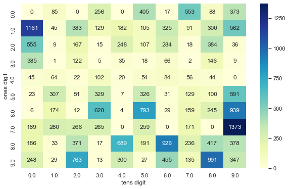

```python
sns.set()
plt.figure(figsize=(10, 6))
sns.heatmap(crosstab, cmap="YlGnBu", annot=True, fmt="d")
plt.xlabel('tens digit')
plt.ylabel('ones digit')
```

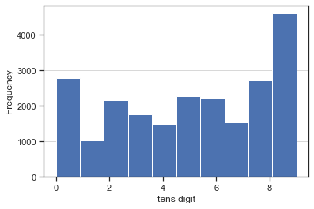

```python
sns.set(style="ticks")
sns.distplot(sub_lst['price_00'], kde=False, bins=10,
            hist_kws = {"alpha": 1})
plt.ylabel('Frequency')
plt.xlabel('tens digit')
plt.grid(axis='y', alpha=0.75)
```

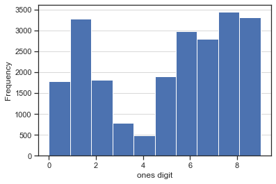

```python
sns.distplot(sub_lst['price_0'],  kde=False, bins=10,
            hist_kws = {"alpha": 1})
plt.ylabel('Frequency')
plt.xlabel('ones digit')
plt.grid(axis='y', alpha=0.75)
```

```python
# adjust price range
sub_lst = listings[listings.price<2300]
```

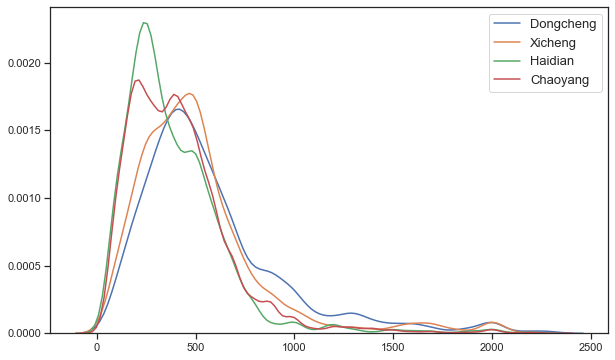

```python
plt.figure(figsize=(10, 6))
sns.kdeplot(sub_lst.price[sub_lst.neighbourhood_cleansed=='东城'], label='Dongcheng')
sns.kdeplot(sub_lst.price[sub_lst.neighbourhood_cleansed=='西城'], label='Xicheng')
sns.kdeplot(sub_lst.price[sub_lst.neighbourhood_cleansed=='海淀'], label='Haidian')
sns.kdeplot(sub_lst.price[sub_lst.neighbourhood_cleansed=='朝阳'], label='Chaoyang')
plt.legend(prop={'size': 13})
```

```python
import warnings
warnings.filterwarnings('ignore')
```

```python
labels = ['东城','西城','海淀','朝阳']
sub_lst = sub_lst[sub_lst.neighbourhood_cleansed.isin(labels)]
```

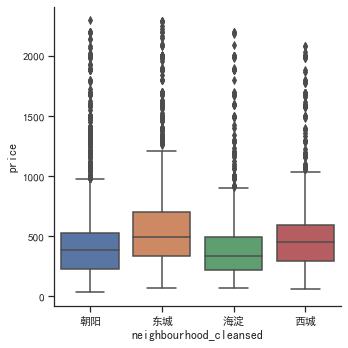

```python
# show chinese
sns.set(style="ticks",font='SimHei')
sns.catplot(x="neighbourhood_cleansed", y="price", kind="box", data=sub_lst)
plt.show()
```

```python
p_diff=sub_lst.groupby('neighbourhood_cleansed')['price'].describe()
p_diff
```

| neighbourhood_cleansed | count | mean | std | min | 25% | 50% | 75% | max |
| --- | --- | --- | --- | --- | --- | --- | --- | --- |
| 东城 | 2959.0 | 576.301453 | 370.732077 | 67.0 | 336.0 | 497.0 | 698.0 | 2288.0 |
| 朝阳 | 9534.0 | 414.007762 | 265.271412 | 34.0 | 228.0 | 382.0 | 530.0 | 2295.0 |
| 海淀 | 2833.0 | 392.481821 | 267.773052 | 67.0 | 221.0 | 336.0 | 497.0 | 2201.0 |
| 西城 | 1481.0 | 510.488184 | 337.040981 | 60.0 | 295.0 | 456.0 | 597.0 | 2080.0 |

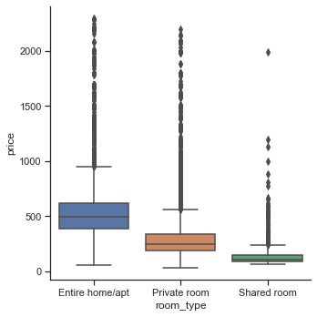

```python
sns.set(style="ticks")
sns.catplot(x="room_type", y="price", kind="box", data=sub_lst)
```

```python
p_diff=sub_lst.groupby('room_type')['price'].describe()
p_diff
```

| room_type | count | mean | std | min | 25% | 50% | 75% | max |
| --- | --- | --- | --- | --- | --- | --- | --- | --- |
| Entire home/apt | 10074.0 | 549.702899 | 286.899506 | 54.0 | 389.0 | 490.0 | 615.5 | 2295.0 |
| Private room | 5570.0 | 326.936086 | 261.571234 | 34.0 | 188.0 | 248.0 | 336.0 | 2201.0 |
| Shared room | 1163.0 | 138.967326 | 116.425117 | 60.0 | 87.0 | 101.0 | 148.0 | 1993.0 |

```python
# pivot table
pt = sub_lst.pivot_table(index="neighbourhood_cleansed", columns="room_type", values="price", aggfunc=[min,mean,max])
pt
```

| room_type neighbourhood_cleansed | min Entire home/apt | min Private room | min Shared room | mean Entire home/apt | mean Private room | mean Shared room | max Entire home/apt | max Private room | max Shared room |
| --- | --- | --- | --- | --- | --- | --- | --- | --- | --- |
| 东城 | 67.0 | 67.0 | 67.0 | 626.798453 | 504.040208 | 166.512605 | 2288.0 | 2201.0 | 1201.0 |
| 朝阳 | 54.0 | 34.0 | 60.0 | 520.702352 | 282.999036 | 137.424033 | 2295.0 | 2141.0 | 1993.0 |
| 海淀 | 74.0 | 67.0 | 67.0 | 546.298433 | 265.302128 | 130.582677 | 2201.0 | 2000.0 | 651.0 |
| 西城 | 107.0 | 67.0 | 60.0 | 561.346622 | 468.742188 | 138.500000 | 2080.0 | 2033.0 | 557.0 |

```python
# number of listings by type in every district
sub_lst = sub_lst[['id','neighbourhood_cleansed','room_type']]
gb = sub_lst.groupby(['neighbourhood_cleansed','room_type']).count().unstack()
gb
```

| room_type neighbourhood_cleansed | id Entire home/apt | id Private room | id Shared room |
| --- | --- | --- | --- |
| 东城 | 2069 | 771 | 119 |
| 朝阳 | 5698 | 3112 | 724 |
| 海淀 | 1404 | 1175 | 254 |
| 西城 | 903 | 512 | 66 |

## Feature engineering

```python
cols = ['price','accommodates','bathrooms','bedrooms','beds','deposit'
        'host_is_superhost','host_has_profile_pic','host_identity_verified','calculated_host_listings_count',
        'review_scores_rating','review_scores_accuracy','review_scores_cleanliness','review_scores_checkin',
        'review_scores_communication','review_scores_location','review_scores_value',
        'cancellation_policy','room_type','neighbourhood_cleansed',
        'number_of_reviews','cleaning_fee','security_deposit']
```

## Price prediction

```python
#+ number_of_reviews + cleaning_fee + security_deposit + minimum_nights]
xtest =data.loc[data['review_scores_rating'].isnull(),list3]
ytest =data.loc[data['review_scores_rating'].isnull(),'price']
x =data.loc[data['review_scores_rating'].notnull(),list3].copy()
y =data.loc[data['review_scores_rating'].notnull(),'price'].copy()

xtrain,xval,ytrain,yval = tts(x,y,test_size=0.3,random_state=222)
```

```python
# split train and test data
from sklearn.model_selection import train_test_split

train_data,test_data = train_test_split(listings,test_size=0.3,random_state=0)
```

### Logistic regression

```python
formula = '''instant_bookable ~ price + accommodates  + bathrooms + bedrooms + beds + deposit
+ host_is_superhost + host_has_profile_pic + host_identity_verified + calculated_host_listings_count
+ C(cancellation_policy) + C(room_type) + C(neighbourhood_cleansed)'''

import statsmodels.api as sm

model = sm.Logit.from_formula(formula, data=listings)
logit = model.fit()
logit.summary()
```

```
Optimization terminated successfully.
         Current function value: 0.621524
         Iterations 6
```

Logit Regression Results

[output not shown]

|  | coef | std err | z | P>\|z\| | [0.025 | 0.975] |
| --- | --- | --- | --- | --- | --- | --- |
| Intercept | 0.9236 | 0.356 | 2.593 | 0.010 | 0.226 | 1.622 |
| C(cancellation_policy)[T.moderate] | -0.2461 | 0.031 | -7.934 | 0.000 | -0.307 | -0.185 |
| C(cancellation_policy)[T.strict_14_with_grace_period] | -0.5060 | 0.034 | -14.716 | 0.000 | -0.573 | -0.439 |
| C(room_type)[T.Private room] | -0.2649 | 0.030 | -8.957 | 0.000 | -0.323 | -0.207 |
| C(room_type)[T.Shared room] | -0.4541 | 0.056 | -8.082 | 0.000 | -0.564 | -0.344 |
| C(neighbourhood_cleansed)[T.丰台] | 0.1530 | 0.065 | 2.340 | 0.019 | 0.025 | 0.281 |
| C(neighbourhood_cleansed)[T.大兴] | 0.1872 | 0.088 | 2.125 | 0.034 | 0.015 | 0.360 |
| C(neighbourhood_cleansed)[T.密云] | 0.3035 | 0.085 | 3.560 | 0.000 | 0.136 | 0.471 |
| C(neighbourhood_cleansed)[T.平谷] | 0.1424 | 0.194 | 0.735 | 0.462 | -0.237 | 0.522 |
| C(neighbourhood_cleansed)[T.延庆] | 0.1162 | 0.092 | 1.256 | 0.209 | -0.065 | 0.297 |
| C(neighbourhood_cleansed)[T.怀柔] | 0.7959 | 0.102 | 7.831 | 0.000 | 0.597 | 0.995 |
| C(neighbourhood_cleansed)[T.房山] | -0.0466 | 0.099 | -0.471 | 0.638 | -0.240 | 0.147 |
| C(neighbourhood_cleansed)[T.昌平] | -0.0428 | 0.078 | -0.549 | 0.583 | -0.196 | 0.110 |
| C(neighbourhood_cleansed)[T.朝阳] | -0.1150 | 0.043 | -2.680 | 0.007 | -0.199 | -0.031 |
| C(neighbourhood_cleansed)[T.海淀] | -0.1895 | 0.053 | -3.573 | 0.000 | -0.293 | -0.086 |
| C(neighbourhood_cleansed)[T.石景山] | 0.0100 | 0.156 | 0.064 | 0.949 | -0.296 | 0.316 |
| C(neighbourhood_cleansed)[T.西城] | -0.1336 | 0.064 | -2.101 | 0.036 | -0.258 | -0.009 |
| C(neighbourhood_cleansed)[T.通州] | -0.3153 | 0.070 | -4.496 | 0.000 | -0.453 | -0.178 |
| C(neighbourhood_cleansed)[T.门头沟] | -0.2194 | 0.177 | -1.239 | 0.215 | -0.566 | 0.128 |
| C(neighbourhood_cleansed)[T.顺义] | 0.2312 | 0.085 | 2.730 | 0.006 | 0.065 | 0.397 |
| price | -2.569e-05 | 8.5e-06 | -3.023 | 0.002 | -4.23e-05 | -9.04e-06 |
| accommodates | -0.0161 | 0.010 | -1.622 | 0.105 | -0.036 | 0.003 |
| bathrooms | 0.0194 | 0.019 | 1.002 | 0.316 | -0.019 | 0.057 |
| bedrooms | -0.0160 | 0.020 | -0.805 | 0.421 | -0.055 | 0.023 |
| beds | 0.0471 | 0.012 | 4.014 | 0.000 | 0.024 | 0.070 |
| host_is_superhost | 0.3176 | 0.034 | 9.302 | 0.000 | 0.251 | 0.384 |
| host_has_profile_pic | 0.1418 | 0.354 | 0.401 | 0.688 | -0.551 | 0.835 |
| host_identity_verified | -0.5124 | 0.033 | -15.728 | 0.000 | -0.576 | -0.449 |
| calculated_host_listings_count | -0.0058 | 0.000 | -13.353 | 0.000 | -0.007 | -0.005 |

### OLS regression

```python
formula = '''price ~ accommodates  + bathrooms + bedrooms + beds + deposit
+ host_is_superhost + host_has_profile_pic + host_identity_verified + calculated_host_listings_count
+ review_scores_accuracy + review_scores_cleanliness + review_scores_checkin
+ review_scores_communication + review_scores_location + review_scores_value
+ C(cancellation_policy) + C(room_type) + C(neighbourhood_cleansed)'''
#+ number_of_reviews + cleaning_fee + security_deposit + minimum_nights

from statsmodels.formula.api import ols

ols = ols(formula, data=listings).fit()
ols.summary()
```

OLS Regression Results

| Dep. Variable: | price | R-squared: | 0.083 |
| --- | --- | --- | --- |
| Model: | OLS | Adj. R-squared: | 0.081 |
| Method: | Least Squares | F-statistic: | 46.14 |
| Date: | Mon, 23 Mar 2020 | Prob (F-statistic): | 7.32e-286 |
| Time: | 18:40:49 | Log-Likelihood: | -1.4516e+05 |
| No. Observations: | 16856 | AIC: | 2.904e+05 |
| Df Residuals: | 16822 | BIC: | 2.907e+05 |
| Df Model: | 33 |  |  |
| Covariance Type: | nonrobust |  |  |

|  | coef | std err | t | P>\|t\| | [0.025 | 0.975] |
| --- | --- | --- | --- | --- | --- | --- |
| Intercept | 312.6458 | 425.459 | 0.735 | 0.462 | -521.298 | 1146.590 |
| C(cancellation_policy)[T.moderate] | -39.4484 | 23.965 | -1.646 | 0.100 | -86.422 | 7.525 |
| C(cancellation_policy)[T.strict_14_with_grace_period] | -35.8748 | 28.115 | -1.276 | 0.202 | -90.984 | 19.234 |
| C(room_type)[T.Private room] | -116.5768 | 24.490 | -4.760 | 0.000 | -164.579 | -68.575 |
| C(room_type)[T.Shared room] | -206.9970 | 49.114 | -4.215 | 0.000 | -303.266 | -110.728 |
| C(neighbourhood_cleansed)[T.丰台] | -222.1774 | 51.064 | -4.351 | 0.000 | -322.267 | -122.087 |
| C(neighbourhood_cleansed)[T.大兴] | -262.0605 | 70.044 | -3.741 | 0.000 | -399.354 | -124.767 |
| C(neighbourhood_cleansed)[T.密云] | -147.5907 | 77.359 | -1.908 | 0.056 | -299.223 | 4.042 |
| C(neighbourhood_cleansed)[T.平谷] | 7.6371 | 196.760 | 0.039 | 0.969 | -378.033 | 393.307 |
| C(neighbourhood_cleansed)[T.延庆] | 58.6474 | 96.983 | 0.605 | 0.545 | -131.448 | 248.743 |
| C(neighbourhood_cleansed)[T.怀柔] | 261.2707 | 85.416 | 3.059 | 0.002 | 93.846 | 428.695 |
| C(neighbourhood_cleansed)[T.房山] | -287.6940 | 86.864 | -3.312 | 0.001 | -457.957 | -117.431 |
| C(neighbourhood_cleansed)[T.昌平] | -66.6067 | 66.102 | -1.008 | 0.314 | -196.173 | 62.960 |
| C(neighbourhood_cleansed)[T.朝阳] | -99.8190 | 31.980 | -3.121 | 0.002 | -162.503 | -37.135 |
| C(neighbourhood_cleansed)[T.海淀] | -91.4993 | 40.152 | -2.279 | 0.023 | -170.201 | -12.797 |
| C(neighbourhood_cleansed)[T.石景山] | -301.1739 | 131.321 | -2.293 | 0.022 | -558.576 | -43.772 |
| C(neighbourhood_cleansed)[T.西城] | -75.5194 | 48.485 | -1.558 | 0.119 | -170.555 | 19.516 |
| C(neighbourhood_cleansed)[T.通州] | -235.0437 | 63.605 | -3.695 | 0.000 | -359.716 | -110.372 |
| C(neighbourhood_cleansed)[T.门头沟] | 69.2614 | 174.477 | 0.397 | 0.691 | -272.731 | 411.254 |
| C(neighbourhood_cleansed)[T.顺义] | -108.5865 | 67.560 | -1.607 | 0.108 | -241.010 | 23.837 |
| accommodates | 81.0573 | 9.499 | 8.533 | 0.000 | 62.437 | 99.677 |
| bathrooms | 80.7167 | 11.196 | 7.209 | 0.000 | 58.771 | 102.663 |
| bedrooms | 137.5751 | 17.996 | 7.645 | 0.000 | 102.301 | 172.850 |
| beds | -8.5913 | 11.138 | -0.771 | 0.441 | -30.423 | 13.241 |
| host_is_superhost | -48.1494 | 23.672 | -2.034 | 0.042 | -94.550 | -1.749 |
| host_has_profile_pic | -7.9077 | 402.323 | -0.020 | 0.984 | -796.504 | 780.688 |
| host_identity_verified | 10.6443 | 25.147 | 0.423 | 0.672 | -38.646 | 59.934 |
| calculated_host_listings_count | -0.2987 | 0.552 | -0.541 | 0.589 | -1.381 | 0.784 |
| review_scores_accuracy | 16.6553 | 20.374 | 0.817 | 0.414 | -23.280 | 56.590 |
| review_scores_cleanliness | -35.7083 | 15.406 | -2.318 | 0.020 | -65.905 | -5.511 |
| review_scores_checkin | -2.7981 | 21.741 | -0.129 | 0.898 | -45.412 | 39.816 |
| review_scores_communication | -46.8710 | 21.852 | -2.145 | 0.032 | -89.704 | -4.038 |
| review_scores_location | 37.0298 | 16.092 | 2.301 | 0.021 | 5.487 | 68.572 |
| review_scores_value | 16.4786 | 17.751 | 0.928 | 0.353 | -18.316 | 51.273 |

| Omnibus: | 48949.276 | Durbin-Watson: | 1.994 |
| --- | --- | --- | --- |
| Prob(Omnibus): | 0.000 | Jarque-Bera (JB): | 2519387001.463 |
| Skew: | 40.309 | Prob(JB): | 0.00 |
| Kurtosis: | 1895.265 | Cond. No. | 1.56e+03 |

Warnings:  
[1] Standard Errors assume that the covariance matrix of the errors is correctly specified.  
[2] The condition number is large, 1.56e+03. This might indicate that there are  
strong multicollinearity or other numerical problems.

```python
import re
wordcloud_use = ' '.join(mean_words.keys())
resultword=re.sub("[A-Za-z0-9\[\`\~\!\@\#\$\^\&\*\(\)\=\|\{\}\'\:\;\'\,\[\]\.\<\>\/\?\~\。\@\#\\\&\*\%]", "",wordcloud_use)

w = WordCloud(scale=4,background_color='white', font_path='msyhbd.ttf',
             max_words = 100,max_font_size = 60,random_state=20).generate(resultword)
plt.imshow(w)
```

```python
path='D:/Data/airbnb/reviews_detail.csv'
reviews = pd.read_csv(path)
reviews.info()
```

```
<class 'pandas.core.frame.DataFrame'>
RangeIndex: 202099 entries, 0 to 202098
Data columns (total 6 columns):
listing_id       202099 non-null int64
id               202099 non-null int64
date             202099 non-null object
reviewer_id      202099 non-null int64
reviewer_name    202093 non-null object
comments         201983 non-null object
dtypes: int64(3), object(3)
memory usage: 9.3+ MB
```

```python
# historical reviews is included
pd.unique(reviews['date'])
```

```
array(['2010-08-25', '2010-10-13', '2011-08-11', ..., '2018-03-31',
       '2018-11-28', '2018-03-22'], dtype=object)
```

```python
path='D:/Data/airbnb/neighbourhoods.csv'
neighbourhoods = pd.read_csv(path)
neighbourhoods.columns.values
```

```
array(['neighbourhood_group', 'neighbourhood'], dtype=object)
```

## Railway stations in Beijing

1. compute the distance of listings to the closest railway station

```python
import requests
import time
# define null in json as None
null = None
# Beijing city code in Baidu map
city_code= 131
# request from the api
# api: http://map.baidu.com/?qt=bsi&c={城市编号}&t={13位时间戳}
station_info = requests.get('http://map.baidu.com/?qt=bsi&c=%s&t=%s' % (city_code, int(time.time() * 1000)))
# json字符串转为python对象
station_info_json = eval(station_info.content)
```

[output not shown]

```python
station_info_json['content']
```

```python
import math

PI = math.pi

def _transformlat(coordinates):
    lng = coordinates[ : , 0] - 105
    lat = coordinates[ : , 1] - 35
    ret = -100 + 2 * lng + 3 * lat + 0.2 * lat * lat + \
          0.1 * lng * lat + 0.2 * np.sqrt(np.fabs(lng))
    ret += (20 * np.sin(6 * lng * PI) + 20 *
            np.sin(2 * lng * PI)) * 2 / 3
    ret += (20 * np.sin(lat * PI) + 40 *
            np.sin(lat / 3 * PI)) * 2 / 3
    ret += (160 * np.sin(lat / 12 * PI) + 320 *
            np.sin(lat * PI / 30.0)) * 2 / 3
    return ret


def _transformlng(coordinates):
    lng = coordinates[ : , 0] - 105
    lat = coordinates[ : , 1] - 35
    ret = 300 + lng + 2 * lat + 0.1 * lng * lng + \
          0.1 * lng * lat + 0.1 * np.sqrt(np.fabs(lng))
    ret += (20 * np.sin(6 * lng * PI) + 20 *
            np.sin(2 * lng * PI)) * 2 / 3
    ret += (20 * np.sin(lng * PI) + 40 *
            np.sin(lng / 3 * PI)) * 2 / 3
    ret += (150 * np.sin(lng / 12 * PI) + 300 *
            np.sin(lng / 30 * PI)) * 2 / 3
    return ret


def gcj02_to_wgs84(coordinates):
    """
    GCJ-02转WGS-84
    :param coordinates: GCJ-02坐标系的经度和纬度的numpy数组
    :returns: WGS-84坐标系的经度和纬度的numpy数组
    """
    ee = 0.006693421622965943  # 偏心率平方
    a = 6378245  # 长半轴
    lng = coordinates[ : , 0]
    lat = coordinates[ : , 1]
    is_in_china= (lng > 73.66) & (lng < 135.05) & (lat > 3.86) & (lat < 53.55)
    _transform = coordinates[is_in_china]  #只对国内的坐标做偏移

    dlat = _transformlat(_transform)
    dlng = _transformlng(_transform)
    radlat = _transform[ : , 1] / 180 * PI
    magic = np.sin(radlat)
    magic = 1 - ee * magic * magic
    sqrtmagic = np.sqrt(magic)
    dlat = (dlat * 180.0) / ((a * (1 - ee)) / (magic * sqrtmagic) * PI)
    dlng = (dlng * 180.0) / (a / sqrtmagic * np.cos(radlat) * PI)
    mglat = _transform[ : , 1] + dlat
    mglng = _transform[ : , 0] + dlng
    coordinates[is_in_china] = np.array([
        _transform[ : , 0] * 2 - mglng, _transform[ : , 1] * 2 - mglat
    ]).T
    return coordinates


def bd09_to_gcj02(coordinates):
    """
    BD-09转GCJ-02
    :param coordinates: BD-09坐标系的经度和纬度的numpy数组
    :returns: GCJ-02坐标系的经度和纬度的numpy数组
    """
    x_pi = PI * 3000 / 180
    x = coordinates[ : , 0] - 0.0065
    y = coordinates[ : , 1] - 0.006
    z = np.sqrt(x * x + y * y) - 0.00002 * np.sin(y * x_pi)
    theta = np.arctan2(y, x) - 0.000003 * np.cos(x * x_pi)
    lng = z * np.cos(theta)
    lat = z * np.sin(theta)
    coordinates = np.array([lng, lat]).T
    return coordinates


def bd09_to_wgs84(coordinates):
    """
    BD-09转WGS-84
    :param coordinates: BD-09坐标系的经度和纬度的numpy数组
    :returns: WGS-84坐标系的经度和纬度的numpy数组
    """
    return gcj02_to_wgs84(bd09_to_gcj02(coordinates))


def mercator_to_bd09(mercator):
    """
    BD-09MC转BD-09
    :param coordinates: GCJ-02坐标系的经度和纬度的numpy数组
    :returns: WGS-84坐标系的经度和纬度的numpy数组
    """
    MCBAND = [12890594.86, 8362377.87, 5591021, 3481989.83, 1678043.12, 0]
    MC2LL = [[1.410526172116255e-08,   8.98305509648872e-06,    -1.9939833816331,
              200.9824383106796,       -187.2403703815547,      91.6087516669843,
              -23.38765649603339,      2.57121317296198,        -0.03801003308653,
              17337981.2],
            [-7.435856389565537e-09,  8.983055097726239e-06,   -0.78625201886289,
             96.32687599759846,       -1.85204757529826,       -59.36935905485877,
             47.40033549296737,       -16.50741931063887,      2.28786674699375,
             10260144.86],
            [-3.030883460898826e-08,  8.98305509983578e-06,    0.30071316287616,
             59.74293618442277,       7.357984074871,          -25.38371002664745,
             13.45380521110908,       -3.29883767235584,       0.32710905363475,
             6856817.37],
            [-1.981981304930552e-08,  8.983055099779535e-06,   0.03278182852591,
             40.31678527705744,       0.65659298677277,        -4.44255534477492,
             0.85341911805263,        0.12923347998204,        -0.04625736007561,
             4482777.06],
            [3.09191371068437e-09,    8.983055096812155e-06,   6.995724062e-05,
             23.10934304144901,       -0.00023663490511,       -0.6321817810242,
             -0.00663494467273,       0.03430082397953,        -0.00466043876332,
             2555164.4],
            [2.890871144776878e-09,   8.983055095805407e-06,   -3.068298e-08,
             7.47137025468032,        -3.53937994e-06,         -0.02145144861037,
             -1.234426596e-05,        0.00010322952773,        -3.23890364e-06,
             826088.5]]

    x = np.abs(mercator[ : , 0])
    y = np.abs(mercator[ : , 1])
    coef = np.array([
           MC2LL[index] for index in
           (np.tile(y.reshape((-1, 1)), (1, 6)) < MCBAND).sum(axis=1)
    ])
    return converter(x, y, coef)


def converter(x, y, coef):
    x_temp = coef[ : ,0] + coef[ : ,1] * np.abs(x)
    x_n = np.abs(y) / coef[ : ,9]
    y_temp = coef[ : ,2] + coef[ : ,3] * x_n + coef[ : ,4] * x_n ** 2 + \
             coef[ : ,5] * x_n ** 3 + coef[ : ,6] * x_n ** 4 + coef[ : ,7] * x_n ** 5 + \
             coef[ : ,8] * x_n ** 6
    x[x < 0] = -1
    x[x >= 0] = 1
    y[y < 0] = -1
    y[y >= 0] = 1
    x_temp *= x
    y_temp *= y
    coordinates = np.array([x_temp, y_temp]).T
    return coordinates
```

```python
import plotly.offline as py
import plotly.graph_objs as go
from plotly.offline import init_notebook_mode
# to show the map in jupyter notebook
init_notebook_mode(connected=True)

mapbox_access_token = ('pk.eyJ1IjoibHVrYXNtYXJ0aW5lbGxpIiwiYSI6ImNpem85dmhwazAyajIyd284dGxhN2VxYnYifQ.HQCmyhEXZUTz3S98FMrVAQ')
# Beijing
layout = go.Layout(
    autosize=True,
    mapbox=dict(
        accesstoken=mapbox_access_token,
        center=dict(
            lat=39.9,
            lon= 116.3
        ),
        pitch=0,
        zoom=10,
    ),
)

color = ('blue', 'green', 'yellow', 'purple', 'orange', 'red', 'violet',
        'navy', 'crimson', 'cyan', 'magenta', 'maroon', 'peru','gold')
# to store data for plotting
data = []
marked = set()
cnt = 0
for line in station_info_json['content']:
    uid = line['line_uid']
    #由于线路包括了来回两个方向，需要排除已绘制线路的反向线路
    if uid in marked:
        continue

    # to store station orginal cordinates under BD-09MC
    plots = []
    # to store station name
    plots_name = []
    for plot in line['stops']:
        plots.append([plot['x'], plot['y']])
        plots_name.append(plot['name'])
    plot_mercator = np.array(plots)
    # convert oringinal coroddinate to WGS84
    plot_coordinates = bd09_to_wgs84(mercator_to_bd09(plot_mercator))

    data.append(
        go.Scattermapbox(
            lon=plot_coordinates[:, 0], #站台经度
            lat=plot_coordinates[:, 1], #站台纬度
            mode='markers+lines',
            name=line['line_name'], #线路名称，显示在图例（legend）上
            text=plots_name, #各个点的名称，鼠标悬浮在点上时显示
            # 设置标记点的参数
            marker=go.scattermapbox.Marker(
                size=10,
                color=color[cnt]
            ),
        )
    )
    marked.add(uid) #添加已绘制线路的uid
    marked.add(line['pair_line_uid']) #添加已绘制线路反向线路的uid
    cnt = (cnt + 1) % len(color)

fig = dict(data=data, layout=layout)
py.iplot(fig) #直接显示地图
#生成html文件并打开
#py.plot(fig, filename='Guangzhou_railway.html')
```

[interactive chart not shown]

```python
def h2(df1, z):
    inrad1 = df1.applymap(radians)
    a = len(df1.columns)
    b = len(z)
    size = [a,b]
    x = np.zeros(size)
    for i in range(b):
        lat2,lon2 = z[i]
        dlon = inrad1.longitude-lon2
        dlat = inrad1.latitude-lat2
        a = np.sin(dlat/2)**2 + np.cos(df1.latitude) * np.cos(lat2) * np.sin(dlon/2)**2
        c = 2 * 1/np.sin(np.sqrt(a))
        km = 6378.2 * c
        np.insert(x,-1,km,axis=1)
    return x
```

```python
# df1 is listings coordinate
ll=['latitude','longitude']
df1 = listings.loc[:,ll]

plots = []
plots_name = []
for line in station_info_json['content']:
    for plot in line['stops']:
        plots.append([plot['x'], plot['y']])
        plots_name.append(plot['name'])
    plot_mercator = np.array(plots)
    # convert oringinal coroddinate to WGS84
    plot_coordinates = bd09_to_wgs84(mercator_to_bd09(plot_mercator))

latitude = []
longitude = []
for j in plot_coordinates:
    latitude.append(j[1])
    longitude.append(j[0])
#c={"latitude" : latitude,
 #  "longitude" : longitude}
# df2 is stations coordinate
#df2 = pd.DataFrame(c)
z = list(zip(latitude,longitude))
```

```python
d = h2(df1,z)
```

[output not shown]

```python
latitude = []
longitude = []
for j in plot_coordinates:
    latitude.append(j[1])
    longitude.append(j[0])
z1 = list(zip(latitude,longitude))
a = list(listings.latitude)
b = list(listings.longitude)
z2 = list(zip(a,b))
```

```python
from geopy import distance
x = []
y = []
for i in range(len(z1)):
    s = []
    for j in range(len(z2)):
        d = distance.distance(z1[i], z2[j]).miles
        s.append(d)
    x.append(min(s))
    y.append(s.index(min(s)))
```

[output not shown]